[figure not shown]

## Three-State Comparison: Virginia, Iowa, and Oregon

This is a descriptive comparison between Iowa, Oregon, and Virginia guided by Opportunity Insights’ [Opportunity Atlas](https://opportunityatlas.org/) and their 2020 [Economic Tracker](https://tracktherecovery.org/) (Chetty et al. 2020a; Opportunity Insights Team 2020). The Opportunity Atlas uses Census data at the neighborhood level to construct an interactive mapping tool that facilitates learning from the visualization of spatial patterns (Opportunity Insights Team 2020). Their goal is to motivate research aimed at establishing the causal effects of economic mobility in support of policies that will increase opportunity. The Economic Tracker was constructed in response to COVID-19 to follow economic activity in near real-time.

Chetty et al. (2014) identified five core neighborhood characteristics that correlate with economic mobility. Neighborhoods with high economic mobility have less residential segregation and income inequality, greater social capital and family stability, and provide a great primary school education. We make our comparisons using this taxonomy and the most current data from the American Community Survey (ACS), MIT federal election data, and the IRS migration data. We present the results through data visualizations aggregated at the county level for Iowa and Oregon and at the county and independent city level for Virginia. The 38 independent cities of Virginia are classified by the Census Bureau as county equivalents. To provide additional insights, each aggregation level is identified using the 2010 Index of Relative Rurality (IRR) [1]. The index uses population size, population density, extent of urbanized area, and distance to the nearest metro area, to construct a continuous measure that provides a multi-faceted measure of rurality. The IRR ranges from the most rural, 1.00, to the most urban, 0.00. The range of the rurality index for our three states is the most urban, Arlington County, VA (0.12) to the most rural, Wheeler County, OR (0.67) (see IRR Figure). To put the value of the index into perspective, the smallest rurality index in the United States is from New York County, NY (0.04) and the largest is from Northwest Arctic Borough, AK (0.89).

This comparison starts by exploring the economic and demographic differences and similarities between the three states then follows with comparisons based on the taxonomy of the five core neighborhood characteristics. Throughout current insights based on the 2020 Economic Tracker are given.

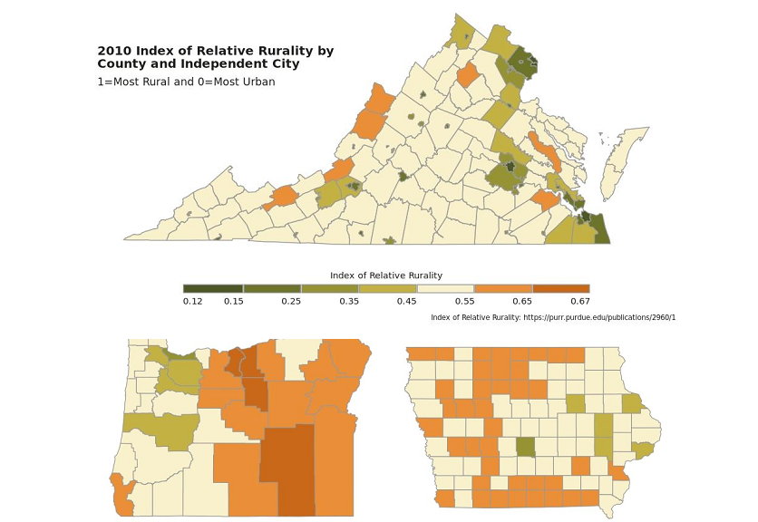

### Economic Comparison

Unlike Iowa, Virginia has maintained its reputation as a friendly business state (CNBC 2019). However, when we look more closely, Virginia is really a story of two states with the economy of the northeast being a center of government, healthcare, finance, and tech and the remainder on agriculture and the service sector ([Statistical Atlas 2020](https://statisticalatlas.com/state/Oregon/Industries)). Virginia has the highest defense spending of any state per capita and contains about 170,000 government jobs, including federal agencies like the National Science Foundation, Central Intelligence Agency, and Department of Defense ([Governing 2019](https://www.governing.com/gov-data/federal-employees-workforce-numbers-by-state.html)). Northeast Virginia is also seen by many as an emerging “Silicon Valley of the East” ([Washington Post 2018](https://www.washingtonpost.com/news/business/wp/2018/06/22/feature/forget-silicon-valley-the-dulles-tech-corridor-is-cultivating-companies-that-break-the-mold/)), largely because of its proximity to Washington D.C. and major infrastructural advantages; in fact, the majority of the internet runs through northern Virginia (Malecki 2002; Richmond Times 2019). On the other hand, southwest Virginia has historical roots in a number of withering industries that include agriculture, manufacturing, coal mining, and railroads. While Virginia has roughly 334,000 ag jobs linked to tobacco, apples, grapes, peanuts, tomatoes, turkeys and broilers ([USDA 2017](https://www.nass.usda.gov/Statistics_by_State/Virginia/); Weldon Cooper 2017), this industry has waned in recent years. Moreover, many of the major cities in Virginia, including Blacksburg, Roanoke, Lynchburg, Richmond, and Norfolk have extremely low rates of economic mobility (see [The Opportunity Atlas](https://www.opportunityatlas.org/)), as these cities have become increasingly dependent on educational institutions and the service industry for jobs. Despite the state being attractive to top businesses, Virginia is the worst state for workers’ rights [2] – suggesting that growing income inequality is a chasm mostly affecting the Virginian working class.

While Oregon’s economy was traditionally based on agriculture and forestry, the state has shifted more toward manufacturing, service, and technology ([Statistical Atlas 2020](https://statisticalatlas.com/state/Oregon/Industries)). Today Oregon’s agricultural industry is predicated on blueberries, almonds, hazelnuts, wine/grapes, cattle, dairy, sheep, poultry, fishing, as well as the timber and forestry industry ([Oregon AIC 2020](https://oregonaitc.org/resources/oregon-resources/oregon-map/)). Despite this industry declining ([Oregon Employment Department 2019](https://www.qualityinfo.org/-/oregon-s-forestry-and-logging-industry-from-planting-to-harvest)), it does not seem that the areas with the lowest economic mobility directly coincide with the areas impacted hardest by loss of private sector jobs in timber (Opportunity Insights Team 2020). Apart from the agricultural sector, Oregon is also known for tourism (mainly in Portland), tech (i.e. Silicon Forest), healthcare (e.g. Cambia and Kaiser) as well as corporate headquarters for clothing, steel, and manufacturing companies. Importantly, Oregon has no sales tax, has low corporate taxes, and relies mostly on personal income - making it more appealing to several high-profile businesses ([Oregon.gov 2020](https://www.oregon.gov/dor/pages/sales-tax.aspx)).

### Demographic Comparison

TABLE 1: Population Change 2010 to 2019

| State | Population 2010 | Population 2019 | Total Area Sq. Miles |
| --- | --- | --- | --- |
| Iowa | 3,046,871 | 3,155,070 | 56,272.81 |
| Oregon | 3,831,079 | 4,217,737 | 98,378.54 |
| Virginia | 8,001,049 | 8,535,519 | 42,774.93 |

Census Quick Fact https://www.census.gov/quickfacts/fact/table/IA,VA,OR/RHI12521

With regard to changes in the age distribution from 2010 to 2019, the age groups with the largest increase (65 to 74 years) and loss (45 to 54 years) are the same for the three states: Iowa +33.78 percent / -20.83 percent, Oregon +46.05 percent / -14.18 percent, and Virginia +37.68 percent / -15.23 percent (1-YR ACS Estimates Table CP05).

These changes can be summarized with the dependency ratio, the ratio of the dependent age population, young (0-17) and old (≥65), to the working age population (18 to 64). The dependency ratio captures the relation between the number of people who aren’t of working age and the number of people who are; the relation between the number of people who pay little or no taxes and the people who pay taxes. The higher the ratio, the greater the burden of support on working people and governments to support the infrastructure that serves the young and the elderly. Low dependency ratios can promote economic growth whereas high dependency ratios can decrease growth since a larger portion of government expenditures will go towards education, healthcare, and pensions.

The age dependency ratio can be partitioned into a child dependency ratio and an old-age dependency ratio. The trend in the U.S. since 2000 has been a decrease in the child dependency ratio and an increase in the old-age ratio, this is also seen across the three states.

TABLE 2: Age, Child, and Old-age Dependency Ratios over Time by State and United States

| State | Dependency Ratio | 2000 | 2010 | 2018 |
| --- | --- | --- | --- | --- |
| Iowa | Child | 41.8 | 39.2 | 38.6 |
|  | Old-age | 24.8 | 24.2 | 27.2 |
|  | Age=Child+Old-age | 66.6 | 63.4 | 65.8 |
| Oregon | Child | 39.6 | 36.1 | 34.3 |
|  | Old-age | 20.5 | 21.2 | 27.0 |
|  | Age=Child+Old-age | 60.1 | 57.3 | 61.3 |
| Virginia | Child | 38.2 | 36.3 | 35.1 |
|  | Old-age | 17.4 | 18.3 | 23.1 |
|  | Age=Child+Old-age | 55.6 | 54.6 | 58.2 |
| United States | Child | 41.5 | 38.7 | 36.8 |
|  | Old-age | 20.1 | 20.3 | 24.6 |
|  | Age=Child+Old-age | 61.6 | 59.0 | 61.4 |

5-YR ACS 2018 Table S0101: https://data.census.gov/cedsci

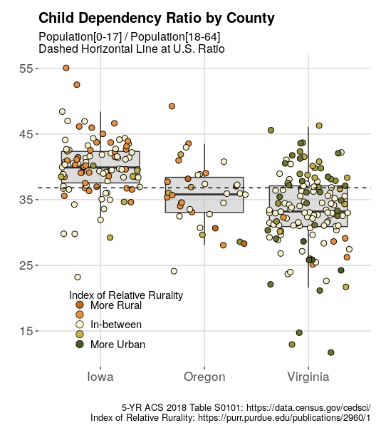

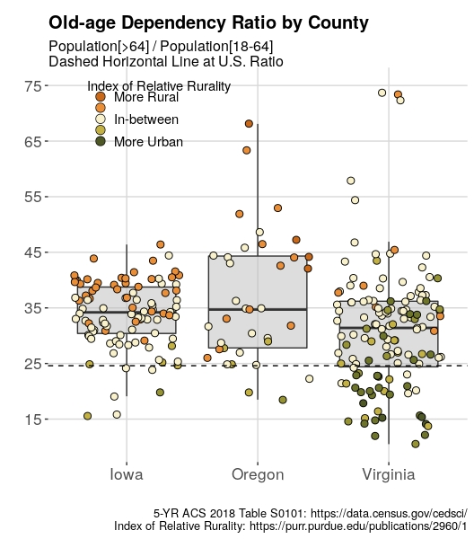

### Footnotes

[1] Waldorf, Brigitte, and Ayoung Kim. 2015. "Defining and Measuring Rurality in the US: From Typologies to Continuous Indices." Commissioned paper prepared for the National Academies of Sciences Workshop on Rationalizing Rural Classifications, April 2015, Washington, D.C. https://sites.nationalacademies.org/cs/groups/dbassesite/documents/webpage/dbasse_168031.pdf.

[2] OXFAM The Best States to Work Index: A Guide to Labor Policies in the United States (2019) https://s3.amazonaws.com/oxfam-us/www/static/media/files/Best_States_to_Work_Index.pdf